# Bayesian Learning: Assignment 2

José Ignacio Díez Ruiz (100487766)

Carlos Roldán Piñero (100484904)

Pablo Vidal Fernández (100483812)

March 2023

Let us start by loading the required packages for the project and fixing the seed.

```r
require("tidyverse")    || is.null(install.packages("tidyverse"))    && require("tidyverse")
require("glmnet")       || is.null(install.packages("glmnet"))       && require("glmnet")
require("MASS")         || is.null(install.packages("MASS"))         && require("MASS")
require("scales")       || is.null(install.packages("scales"))       && require("scales")
require("testit")       || is.null(install.packages("testit"))       && require("testit")
require("fitdistrplus") || is.null(install.packages("fitdistrplus")) && require("fitdistrplus")
require("MCMCglmm")     || is.null(install.packages("MCMCglmm"))     && require("MCMCglmm")
require("monomvn")      || is.null(install.packages("monomvn"))      && require("monomvn")
require("patchwork")    || is.null(install.packages("patchwork"))    && require("patchwork")

set.seed(42)
```

We will also require a root mean square error function to be used later when testing the different fits.

```r
rmse <- function(y_pred, y){ #not designed for readability
  assert("Different lengths for inputs!",
         length(y_pred) == length(y))
  (y_pred - y)             %>%
    (\(x) x / length(x))() |>
    #· We are testing the limits of R ·#
    (\(x) x * x)()         |>
    sum()                  %>%
    sqrt()
}
```

# Introduction

We have chosen a dataset which includes the housing prices for a region, along with different factors. The idea is to try and see whether we may predict the price based on the rest of predictors.

We have the following variables:

- Overall Quality: rates the overall material and finish of the house.
- Overall Condition: rates the overall condition of the house.
- Number of years since remodelation of the house.
- Masonry veneer area: in square feet.
- Finished basement area of type 1: in square feet.
- Total area of finished basement: in square feet.
- First floor area: in square feet.
- Above ground living area: in square feet.
- Full bathrooms above grade.
- Kitchens above grade.
- Total rooms above grade (not counting bathrooms).
- Number of fireplaces.
- Year of construction of the garage.
- Size of garage in car capacity.
- Total area of garage: in square feet.
- Price of the sale.

All of the variables are quantitative.

Let us peek into the data:

```r
data <- read.csv("bayesian_regression_data.csv", sep = ";")
head(data, 5)
```

```
##   OverallQual OverallCond YearRemodAdd MasVnrArea BsmtFinSF1 TotalBsmtSF
## 1           7           5            5        196        706         856
## 2           6           8           31          0        978        1262
## 3           7           5            6        162        486         920
## 4           7           5           36          0        216         756
## 5           8           5            8        350        655        1145
##   X1stFlrSF GrLivArea FullBath KitchenAbvGr TotRmsAbvGrd Fireplaces GarageYrBlt
## 1       856      1710        2            1            8          0        2003
## 2      1262      1262        2            1            6          1        1976
## 3       920      1786        2            1            6          1        2001
## 4       961      1717        1            1            7          1        1998
## 5      1145      2198        2            1            9          1        2000
##   GarageCars GarageArea SalePrice
## 1          2        548    208500
## 2          2        460    181500
## 3          2        608    223500
## 4          3        642    140000
## 5          3        836    250000
```

We will split our data into a train and test partition to compare the different fits.

```r
p         <- 0.8
n         <- nrow(data)
train_idx <- sample(1:n, round(n*p), replace = F)

train     <- data[ train_idx, ]
test      <- data[-train_idx, ]
x_train   <- data[ train_idx, -16]
x_test    <- data[-train_idx, -16]
y_train   <- data[ train_idx,  16]
y_test    <- data[-train_idx,  16]
```

Lastly, because we will later use methods like Lasso, we already prepare a scaled train data set for later.

```r
sc   <- scale(train)
x_sc <- sc[, -16]
y_sc <- sc[,  16]
```

# Frequentist Approach

We start with the frequentist approach. First, we fit a model in which we use all of the variables as predictors

```r
fit_full_frequentist  <- lm(SalePrice ~ ., data = train)
pred_full_frequentist <- predict(fit_full_frequentist, x_test)
summary(fit_full_frequentist)
```

```
##
## Call:
## lm(formula = SalePrice ~ ., data = train)
##
## Residuals:
##     Min      1Q  Median      3Q     Max
## -468296  -17432   -1636   13818  285769
##
## Coefficients:
##                Estimate Std. Error t value Pr(>|t|)
## (Intercept)  -2.701e+05  1.425e+05  -1.895 0.058316 .
## OverallQual   1.813e+04  1.310e+03  13.842  < 2e-16 ***
## OverallCond   2.828e+03  1.095e+03   2.584 0.009891 **
## YearRemodAdd -3.430e+02  7.558e+01  -4.538 6.27e-06 ***
## MasVnrArea    3.938e+01  6.802e+00   5.789 9.10e-09 ***
## BsmtFinSF1    1.853e+01  2.884e+00   6.425 1.93e-10 ***
## TotalBsmtSF   1.009e+01  4.665e+00   2.164 0.030703 *
## X1stFlrSF     1.094e+01  5.338e+00   2.049 0.040693 *
## GrLivArea     2.378e+01  4.897e+00   4.855 1.37e-06 ***
## FullBath      6.173e+03  3.047e+03   2.026 0.043029 *
## KitchenAbvGr -2.738e+04  5.463e+03  -5.011 6.27e-07 ***
## TotRmsAbvGrd  5.077e+03  1.268e+03   4.005 6.60e-05 ***
## Fireplaces    7.821e+03  2.035e+03   3.843 0.000128 ***
## GarageYrBlt   1.094e+02  7.133e+01   1.534 0.125317
## GarageCars    1.332e+04  3.389e+03   3.929 9.05e-05 ***
## GarageArea    2.987e+00  1.176e+01   0.254 0.799526
## ---
## Signif. codes:  0 '***' 0.001 '**' 0.01 '*' 0.05 '.' 0.1 ' ' 1
##
## Residual standard error: 36610 on 1152 degrees of freedom
## Multiple R-squared:  0.786,  Adjusted R-squared:  0.7832
## F-statistic:   282 on 15 and 1152 DF,  p-value: < 2.2e-16
```

We observe that there are several non-important variables. Out target is to get rid of them and use a smaller selection of predictors using Lasso with the one standard error rule to find parameter.

```r
optimal_lambda <- 0.0

for (i in 1:10) {
    cv_lasso       <- cv.glmnet(x_sc, y_sc, alpha = 1, nfolds = 10)
    optimal_lambda <- optimal_lambda + cv_lasso$lambda.1se #1SE rule
}

optimal_lambda   <- optimal_lambda / 10
mod_lasso        <- glmnet(x_sc, y_sc, alpha = 1, lambda = optimal_lambda)
selected_idx     <- which(mod_lasso$beta != 0)
selected_vars    <- rownames(mod_lasso$beta)[selected_idx]

lhs_formula_fit  <- "SalePrice ~ "
rhs_formula_fit  <- paste(selected_vars, collapse = " + ")
formula_fit      <- as.formula(paste(lhs_formula_fit, rhs_formula_fit))
```

The predictors considered by Lasso are the following ones:

```r
selected_vars
```

```
## [1] "OverallQual"  "YearRemodAdd" "MasVnrArea"   "BsmtFinSF1"   "TotalBsmtSF"
## [6] "X1stFlrSF"    "GrLivArea"    "GarageCars"   "GarageArea"
```

Now we can repeat the fit but only using the predictors considered by Lasso.

```r
fit_lasso_frequentist  <- lm(formula_fit, data = train)
pred_lasso_frequentist <- predict(fit_lasso_frequentist, x_test)
summary(fit_lasso_frequentist)
```

```
##
## Call:
## lm(formula = formula_fit, data = train)
##
## Residuals:
##     Min      1Q  Median      3Q     Max
## -481642  -17268   -1061   14698  274365
##
## Coefficients:
##                Estimate Std. Error t value Pr(>|t|)
## (Intercept)  -57481.962   7122.306  -8.071 1.74e-15 ***
## OverallQual   20837.863   1261.614  16.517  < 2e-16 ***
## YearRemodAdd   -432.946     64.493  -6.713 2.98e-11 ***
## MasVnrArea       38.447      6.954   5.529 3.99e-08 ***
## BsmtFinSF1       19.003      2.869   6.623 5.36e-11 ***
## TotalBsmtSF       8.649      4.722   1.832   0.0673 .
## X1stFlrSF         9.665      5.310   1.820   0.0690 .
## GrLivArea        39.341      3.000  13.113  < 2e-16 ***
## GarageCars    15625.567   3361.219   4.649 3.72e-06 ***
## GarageArea        1.045     11.538   0.091   0.9279
## ---
## Signif. codes:  0 '***' 0.001 '**' 0.01 '*' 0.05 '.' 0.1 ' ' 1
##
## Residual standard error: 37530 on 1158 degrees of freedom
## Multiple R-squared:  0.7738, Adjusted R-squared:  0.7721
## F-statistic: 440.2 on 9 and 1158 DF,  p-value: < 2.2e-16
```

Another approach is to include and exclude variables sequentially and, using the Bayesian Information Criteria (BIC) select the best model, as the one that minimizes the BIC. Once again we start with all variables as predictors.

```r
fit_step_frequentist  <- stepAIC(fit_full_frequentist,
                                 k = log(n), trace = FALSE)
pred_step_frequentist <- predict(fit_step_frequentist, x_test)
summary(fit_step_frequentist)
```

```
##
## Call:
## lm(formula = SalePrice ~ OverallQual + YearRemodAdd + MasVnrArea +
##     BsmtFinSF1 + TotalBsmtSF + GrLivArea + KitchenAbvGr + TotRmsAbvGrd +
##     Fireplaces + GarageCars, data = train)
##
## Residuals:
##     Min      1Q  Median      3Q     Max
## -473754  -17694   -1729   14504  288100
##
## Coefficients:
##                Estimate Std. Error t value Pr(>|t|)
## (Intercept)  -33470.735   9209.236  -3.634 0.000291 ***
## OverallQual   18574.165   1274.499  14.574  < 2e-16 ***
## YearRemodAdd   -459.343     63.767  -7.203 1.06e-12 ***
## MasVnrArea       38.813      6.818   5.693 1.58e-08 ***
## BsmtFinSF1       18.704      2.848   6.568 7.71e-11 ***
## TotalBsmtSF      15.821      3.349   4.724 2.59e-06 ***
## GrLivArea        27.678      4.521   6.122 1.27e-09 ***
## KitchenAbvGr -24982.719   5286.630  -4.726 2.58e-06 ***
## TotRmsAbvGrd   5166.926   1265.701   4.082 4.77e-05 ***
## Fireplaces     8024.492   1989.151   4.034 5.84e-05 ***
## GarageCars    15552.011   1872.549   8.305 2.76e-16 ***
## ---
## Signif. codes:  0 '***' 0.001 '**' 0.01 '*' 0.05 '.' 0.1 ' ' 1
##
## Residual standard error: 36780 on 1157 degrees of freedom
## Multiple R-squared:  0.783,  Adjusted R-squared:  0.7811
## F-statistic: 417.4 on 10 and 1157 DF,  p-value: < 2.2e-16
```

Now is time to compare the three models. We will take the best as the “control” for the latter comparison with Bayesian methods.

```r
(rmse_frequentist <- data.frame(
    full  = rmse(pred_full_frequentist,  y_test),
    lasso = rmse(pred_lasso_frequentist, y_test),
    step  = rmse(pred_step_frequentist,  y_test)
))
```

```
##       full   lasso     step
## 1 2099.026 2062.35 2097.832
```

# Bayesian Approach

Now, for the Bayesian approach, we are going to use the `MCMCglmm` function from the namesake package. To start with, we will use all variables and we will use a non-informative prior (default value already in the function, with $m=0$ and $V = 10^{10} \cdot I$)

```r
f <- formula(paste("SalePrice ~", paste(names(x_train), collapse = " + ")))
base_bayes_model <- MCMCglmm(f, data = train, verbose = FALSE)
bayesian_preds   <- predict(base_bayes_model, test)
summary(base_bayes_model)
```

```
##
##  Iterations = 3001:12991
##  Thinning interval  = 10
##  Sample size  = 1000
##
##  DIC: 27879.44
##
##  R-structure:  ~units
##
##       post.mean  l-95% CI  u-95% CI eff.samp
## units 1.341e+09 1.238e+09 1.448e+09    913.4
##
##  Location effects: SalePrice ~ OverallQual + OverallCond + YearRemodAdd + MasVnrArea + BsmtFinSF1 + TotalBsmtSF + X1stFlrSF + GrLivArea + FullBath + KitchenAbvGr + TotRmsAbvGrd + Fireplaces + GarageYrBlt + GarageCars + GarageArea
##
##               post.mean   l-95% CI   u-95% CI eff.samp  pMCMC
## (Intercept)  -9.001e+04 -2.567e+05  6.602e+04   1230.0  0.268
## OverallQual   1.833e+04  1.576e+04  2.099e+04   1000.0 <0.001 ***
## OverallCond   2.289e+03  1.264e+02  4.364e+03    821.6  0.030 *
## YearRemodAdd -3.893e+02 -5.290e+02 -2.515e+02   1000.0 <0.001 ***
## MasVnrArea    3.986e+01  2.648e+01  5.241e+01    820.2 <0.001 ***
## BsmtFinSF1    1.872e+01  1.328e+01  2.422e+01   1000.0 <0.001 ***
## TotalBsmtSF   1.014e+01  1.195e+00  1.945e+01   1000.0  0.042 *
## X1stFlrSF     1.037e+01  2.850e-01  2.122e+01    904.8  0.042 *
## GrLivArea     2.290e+01  1.311e+01  3.226e+01   1000.0 <0.001 ***
## FullBath      7.074e+03  1.206e+03  1.249e+04   1000.0  0.010 *
## KitchenAbvGr -2.785e+04 -3.765e+04 -1.662e+04   1118.9 <0.001 ***
## TotRmsAbvGrd  5.002e+03  2.679e+03  7.518e+03   1000.0 <0.001 ***
## Fireplaces    7.549e+03  3.727e+03  1.142e+04   1000.0 <0.001 ***
## GarageYrBlt   1.961e+01 -6.555e+01  9.786e+01   1214.7  0.622
## GarageCars    1.326e+04  6.353e+03  1.967e+04   1000.0 <0.001 ***
## GarageArea    7.180e+00 -1.303e+01  3.172e+01   1000.0  0.514
## ---
## Signif. codes:  0 '***' 0.001 '**' 0.01 '*' 0.05 '.' 0.1 ' ' 1
```

Let’s plot the posterior distribution of all the parameters of the model, along with its traces and ACFs.

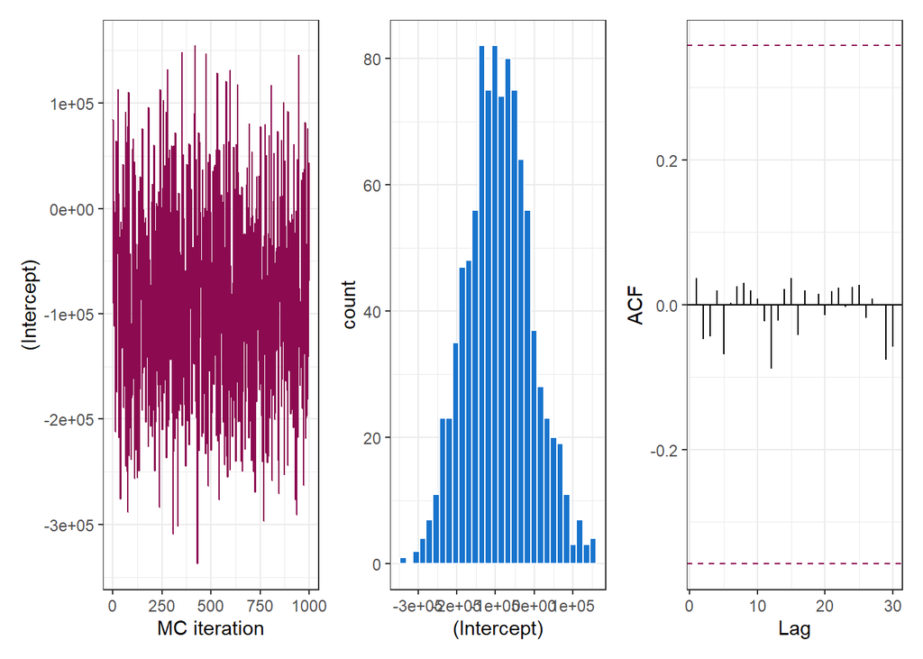

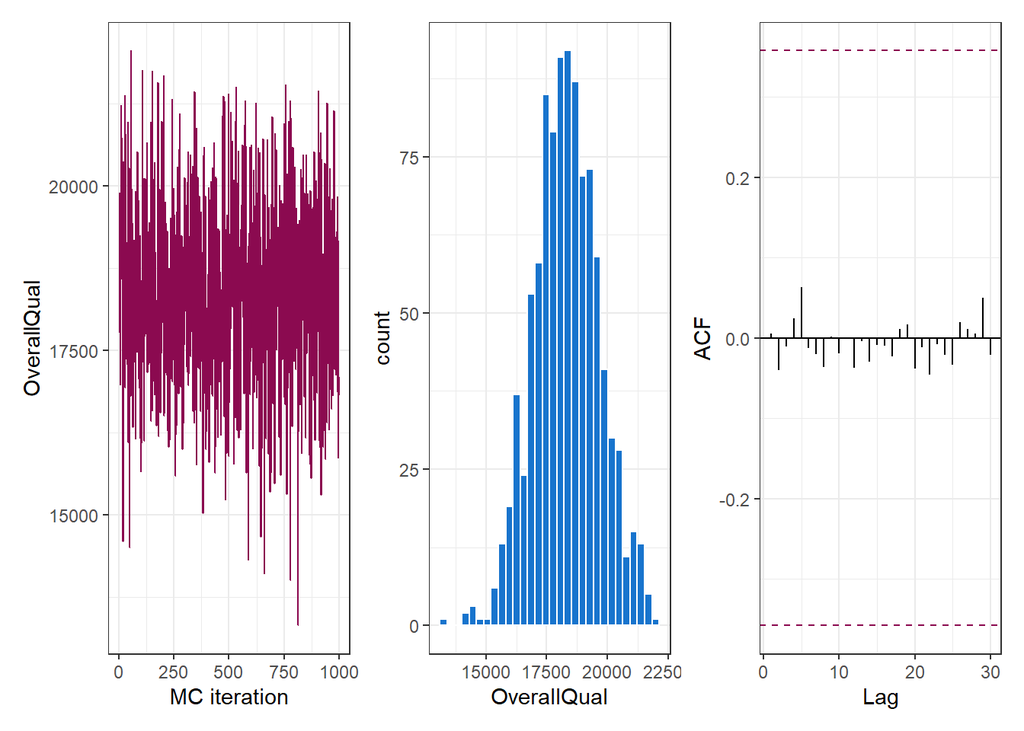

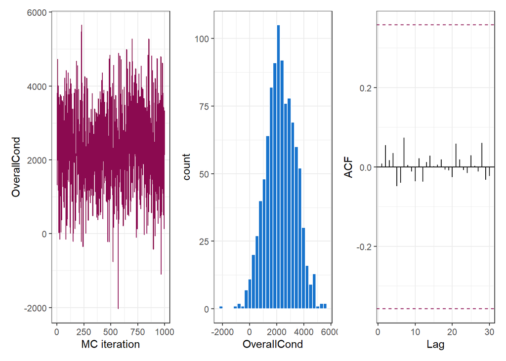

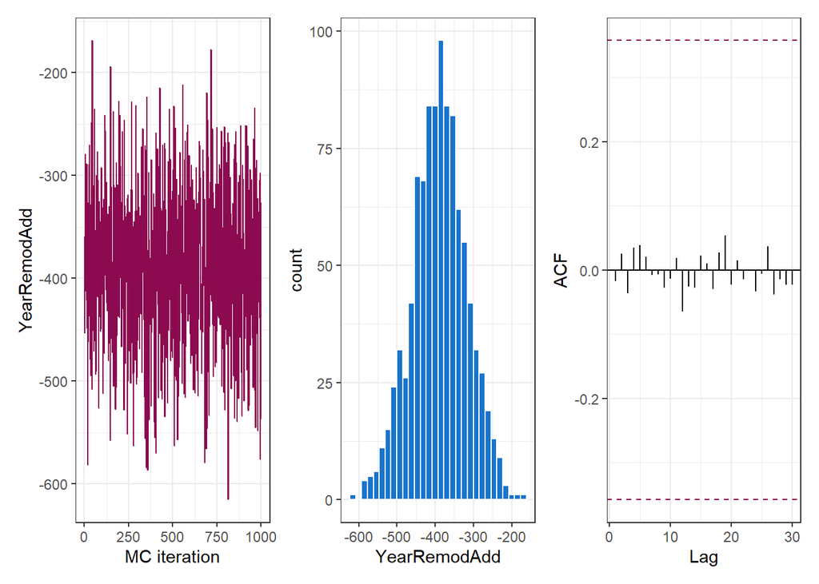

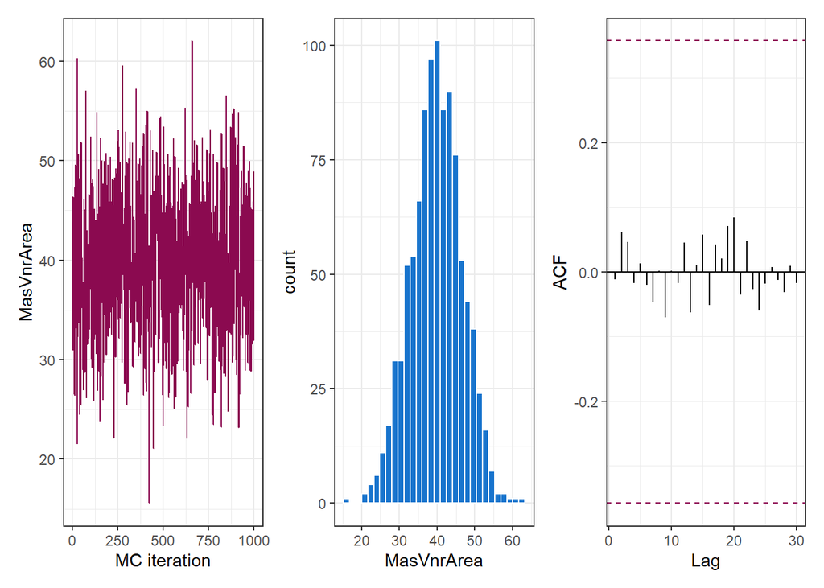

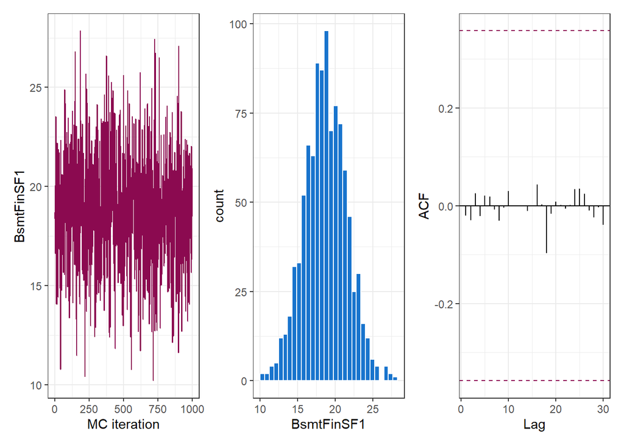

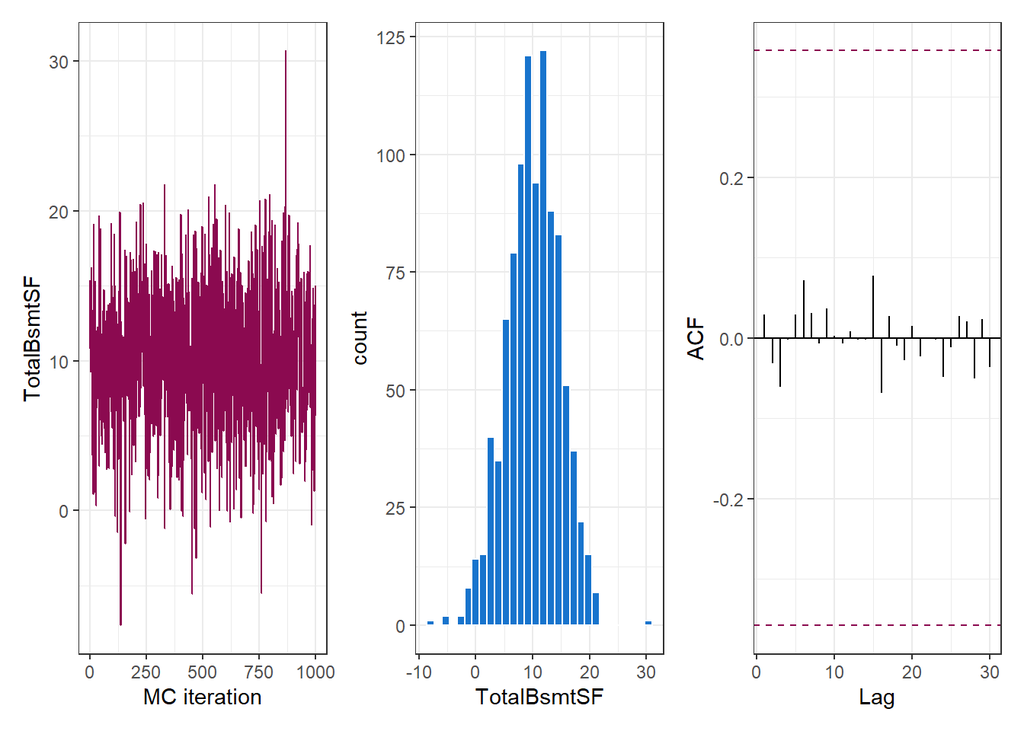

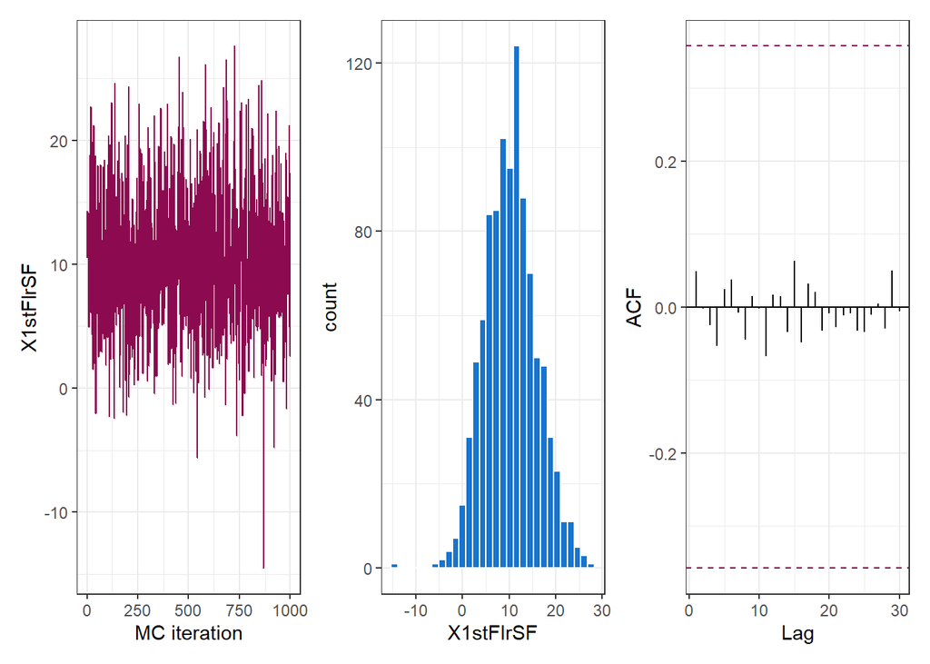

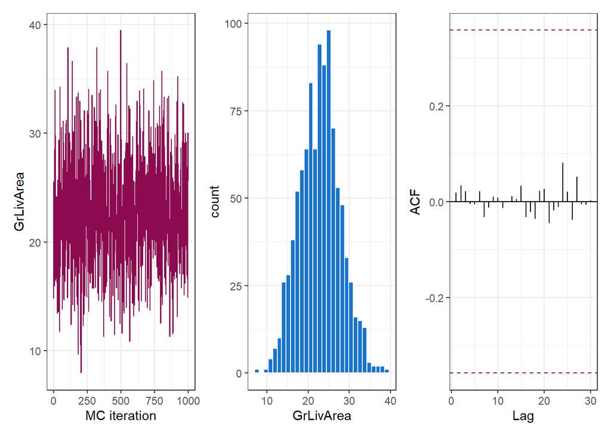

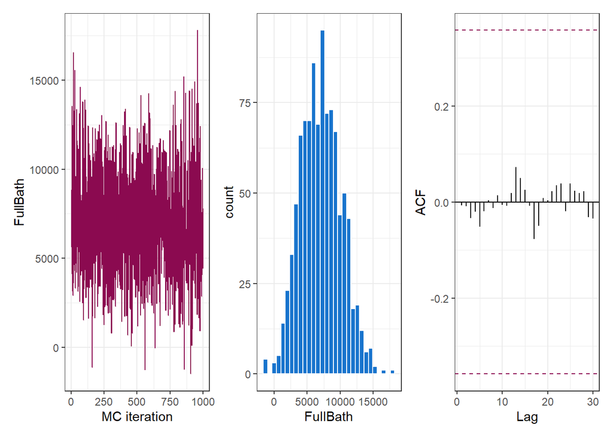

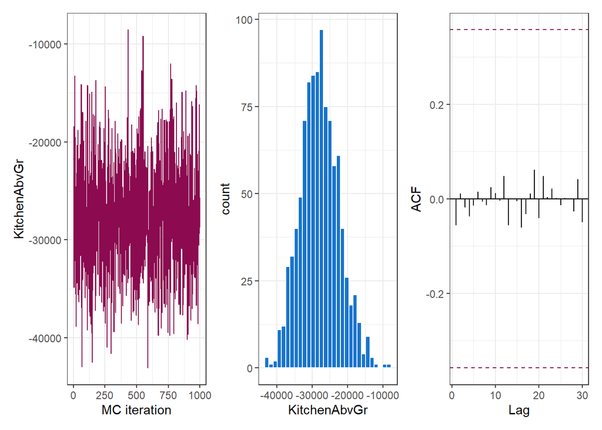

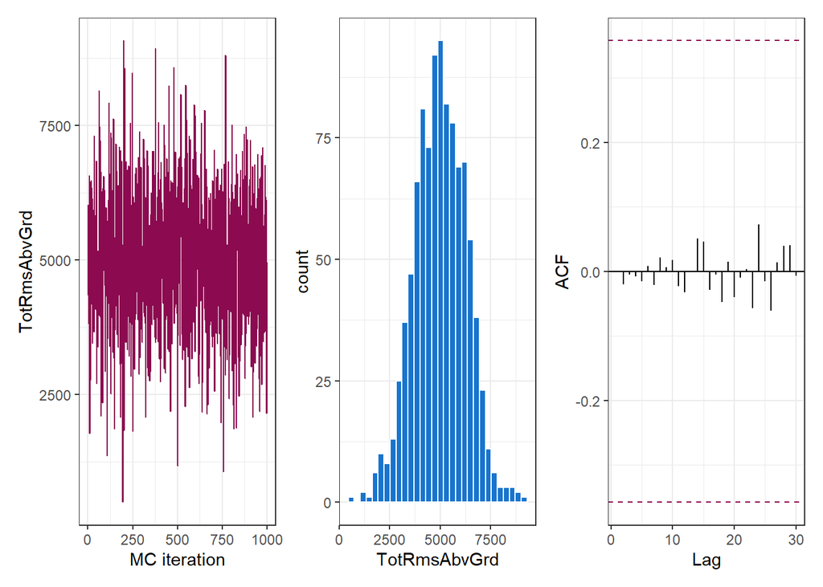

[4 more figures not shown]

```r
traces    <- as.data.frame(base_bayes_model$Sol)
var_names <- c("(Intercept)", names(x_train))
for (v in var_names) {
    p1 <- traces[v] %>%
        ggplot(aes(x = as.numeric(row.names(traces)), y = .data[[v]])) +
            geom_line(col = "deeppink4") + xlab("MC iteration") + theme_bw()
    p2 <- traces[v] %>%
        ggplot(aes(x = .data[[v]])) +
        geom_histogram(col = "white", fill = "dodgerblue3", bins = 30) + theme_bw()

    temp <- as.data.frame(acf(traces[v], plot = FALSE)$acf[-1, , 1 ])
    temp <- cbind(temp, as.numeric(rownames(temp)))
    colnames(temp) <- c("acf", "lag")

    p3 <- temp %>%
        ggplot(aes(x = lag, y = acf)) +
            geom_hline(aes(yintercept = 0)) +
            geom_segment(mapping = aes(xend = lag, yend = 0)) +
            geom_hline(aes(yintercept = 1.959964/sqrt(nrow(temp))),
                       linetype = 2, col = "deeppink4") +
            geom_hline(aes(yintercept = -1.959964/sqrt(nrow(temp))),
                       linetype = 2, col = "deeppink4") +
            xlab("Lag") + ylab("ACF") + theme_bw()

    print(p1 | p2 | p3)
}
```

We can compare the values of the parameters obtained with the frequentist and bayesian approach:

```r
f_vs_b <- cbind(fit_full_frequentist$coefficients, colMeans(base_bayes_model$Sol))
colnames(f_vs_b) <- c("Frequentist","Bayesian")
format(f_vs_b, scientific = 999)
```

```
##              Frequentist      Bayesian
## (Intercept)  "-270124.464240" " -90009.363158"
## OverallQual  "  18127.999053" "  18326.151971"
## OverallCond  "   2828.203460" "   2288.875660"
## YearRemodAdd "   -342.965374" "   -389.315576"
## MasVnrArea   "     39.381754" "     39.855935"
## BsmtFinSF1   "     18.529579" "     18.722659"
## TotalBsmtSF  "     10.093217" "     10.137428"
## X1stFlrSF    "     10.938027" "     10.374395"
## GrLivArea    "     23.776142" "     22.902870"
## FullBath     "   6172.554101" "   7074.389136"
## KitchenAbvGr " -27375.865262" " -27854.931767"
## TotRmsAbvGrd "   5077.204971" "   5002.310911"
## Fireplaces   "   7820.851422" "   7548.636766"
## GarageYrBlt  "    109.417081" "     19.606722"
## GarageCars   "  13316.153415" "  13260.332051"
## GarageArea   "      2.986633" "      7.180216"
```

The values are very similar to the ones obtained with the classical MLE. This is because we have used non-informative priors.

And check the RMSE of the Bayesian model:

```r
rmse(bayesian_preds,y_test)
```

```
## [1] 2100.984
```

It is also very similar to the ones obtained with classical MLE.

## Using a manual prior distibution

We will use a prior $\mathcal{N}(\mu_i,\,\frac{1}{\lambda})$ for every parameter where:

- $\mu_i$ equals $1$ if we think that the variable $i$ will have a positive impact on the price and $-1$ otherwise.
- $\lambda = \frac{1}{10^5}$

The selected values for each variable are the following:

- Overall Quality -> 1
- Overall Condition -> 1
- Number of years since remodelation of the house -> -1
- Masonry veneer area -> 1
- Finished basement area of type 1 -> 1
- Total area of finished basement -> 1
- First floor area -> 1
- Above ground living area -> 0
- Full bathrooms above grade -> 1
- Kitchens above grade -> 1
- Total rooms above grade -> 1
- Number of fireplaces -> 1
- Year of construction of the garage -> 1
- Size of garage in car capacity -> 1
- Total area of garage -> 1

Setting the lambda and prior distribution values:

```r
lambda    <- 1e-5
reg.prior <- list(
    B = list(
      mu = c((1),1,1,-1,1,1,1,1,0,1,1,1,1,1,1,1),
      V  = diag(rep(1/lambda,length(x_train) + 1)))
)
```

Next, we train the model and make the predictions:

```r
base_bayes_model_mprior <- MCMCglmm(f, prior = reg.prior,
                                       data = train,
                                       verbose = FALSE)
bayesian_mprior_preds   <- predict(base_bayes_model_mprior, test)
```

In the following chunk, the summary of the model can be seen:

```r
summary(base_bayes_model_mprior)
```

```
##
##  Iterations = 3001:12991
##  Thinning interval  = 10
##  Sample size  = 1000
##
##  DIC: 28192.04
##
##  R-structure:  ~units
##
##       post.mean  l-95% CI  u-95% CI eff.samp
## units 1.766e+09 1.638e+09 1.914e+09     1000
##
##  Location effects: SalePrice ~ OverallQual + OverallCond + YearRemodAdd + MasVnrArea + BsmtFinSF1 + TotalBsmtSF + X1stFlrSF + GrLivArea + FullBath + KitchenAbvGr + TotRmsAbvGrd + Fireplaces + GarageYrBlt + GarageCars + GarageArea
##
##              post.mean l-95% CI u-95% CI eff.samp  pMCMC
## (Intercept)    -10.702 -640.317  567.307   1206.7  0.958
## OverallQual   1099.146  465.249 1664.870   1000.0 <0.001 ***
## OverallCond    106.059 -400.835  711.538   1000.0  0.726
## YearRemodAdd  -870.314 -994.745 -745.838   1000.0 <0.001 ***
## MasVnrArea      56.633   41.037   72.247   1000.0 <0.001 ***
## BsmtFinSF1      14.365    8.953   21.200   1000.0 <0.001 ***
## TotalBsmtSF     27.553   19.016   37.366   1000.0 <0.001 ***
## X1stFlrSF       -1.046  -12.831    9.788   1000.0  0.854
## GrLivArea       57.540   50.841   63.444   1000.0 <0.001 ***
## FullBath       100.797 -456.509  723.663    898.5  0.764
## KitchenAbvGr  -148.433 -754.430  450.116   1000.0  0.628
## TotRmsAbvGrd    98.251 -401.357  757.103   1000.0  0.800
## Fireplaces     312.460 -332.575  849.988   1000.0  0.312
## GarageYrBlt     15.904   10.125   21.731   1000.0 <0.001 ***
## GarageCars     188.283 -414.672  869.296    870.3  0.562
## GarageArea      69.152   54.947   82.979    995.1 <0.001 ***
## ---
## Signif. codes:  0 '***' 0.001 '**' 0.01 '*' 0.05 '.' 0.1 ' ' 1
```

Finally, let’s compute the RMSE for the model:

```r
rmse(bayesian_mprior_preds, y_test)
```

```
## [1] 2233.119
```

It is worse than for the model with uninformative prior distibution. Probably, the a priori distribution that we have provided is not good enough and it is necessary to be an expert in the field in which you are working to be able to provide an informative prior distribution.

## Blasso

Next, let’s perform a Bayesian lasso (or BLASSO) to perform the variable selection:

```r
blasso_model <- blasso(x_train, y_train, verb=0)
```

After that, let’s plot the frequency of the number of variables used:

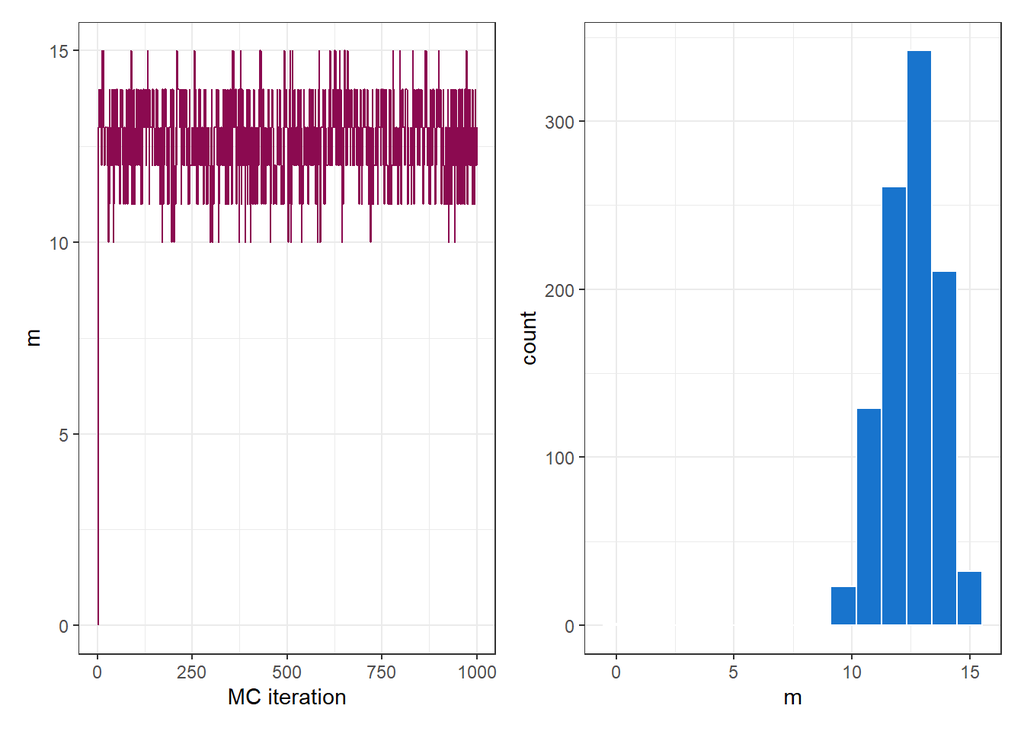

```r
pb <- as.data.frame(blasso_model$m)

pl <- pb %>%
        ggplot(aes(x = as.numeric(rownames(pb)), y = blasso_model$m)) +
            geom_line(col="deeppink4") +
            xlab("MC iteration") + ylab("m") + theme_bw()

ph <- pb %>%
    ggplot(aes(x = blasso_model$m)) + theme_bw() + xlab("m") +
    geom_histogram(col="white", fill="dodgerblue3", bins = 15)

pl | ph
```

It can be seen that the number of variables most often used is 13, although 12 and 14 are also used a large number of times.

The distribution of the values of the different coefficients can be seen in the following chart:

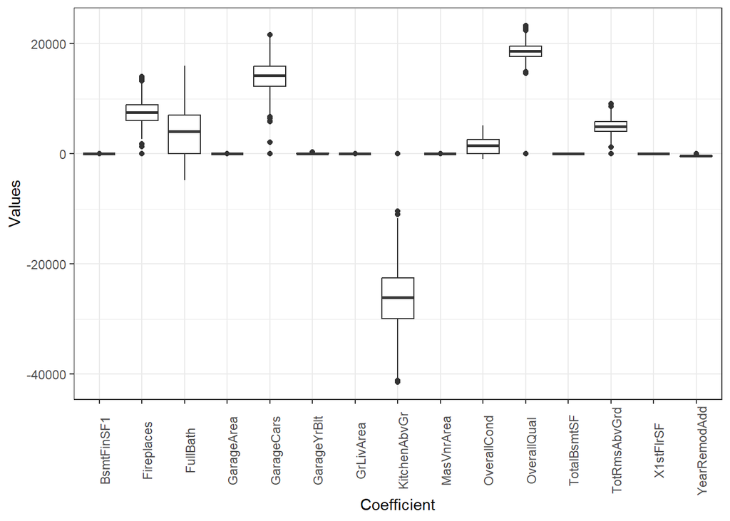

```r
bd <- as.data.frame(blasso_model$beta)
colnames(bd) <- names(x_train)
bd <- bd %>%
        pivot_longer(cols = names(bd), names_to = "Coefficient", values_to = "Values")

bd %>%
    ggplot(aes(x = Coefficient, y = Values)) +
    geom_boxplot() + theme_bw() +
    theme(axis.text.x = element_text(angle = 90))
```

We can see the probability that each coefficient of the regression is different from 0 with the following code:

```r
summary(blasso_model)$bn0
```

```
##   b.1   b.2   b.3   b.4   b.5   b.6   b.7   b.8   b.9  b.10  b.11  b.12  b.13
## 0.999 0.642 0.999 0.999 0.998 0.804 0.757 0.999 0.671 0.999 0.997 0.994 0.454
##  b.14  b.15
## 0.998 0.360
```

As we want to select variables, we will keep those variables for which the coefficient has a probability greater than 95% of being different from 0.

```r
(selected <- names(x_train)[summary(blasso_model)$bn0 > 0.95])
```

```
## [1] "OverallQual"  "YearRemodAdd" "MasVnrArea"   "BsmtFinSF1"   "GrLivArea"
## [6] "KitchenAbvGr" "TotRmsAbvGrd" "Fireplaces"   "GarageCars"
```

And we generate a new Bayesian model using only these variables. First, we need to create the formula:

```r
lhs_formula  <- "SalePrice ~ "
rhs_formula  <- paste(selected, collapse = " + ")
full_formula <- as.formula(paste(lhs_formula, rhs_formula))
```

With the formula already generated, we can train the model and make the predictions.

```r
blasso_bayes_model <- MCMCglmm(full_formula, data = train, verbose = FALSE)
basso_preds        <- predict(blasso_bayes_model, test)
```

The summary of the model can be seen in the following chunk:

```r
summary(blasso_bayes_model)
```

```
##
##  Iterations = 3001:12991
##  Thinning interval  = 10
##  Sample size  = 1000
##
##  DIC: 27905.76
##
##  R-structure:  ~units
##
##       post.mean  l-95% CI  u-95% CI eff.samp
## units 1.382e+09 1.275e+09 1.494e+09     1000
##
##  Location effects: SalePrice ~ OverallQual + YearRemodAdd + MasVnrArea + BsmtFinSF1 + GrLivArea + KitchenAbvGr + TotRmsAbvGrd + Fireplaces + GarageCars
##
##              post.mean  l-95% CI  u-95% CI eff.samp  pMCMC
## (Intercept)  -33166.48 -52156.95 -16278.94   1000.0 <0.001 ***
## OverallQual   20006.57  17513.64  22318.00   1115.7 <0.001 ***
## YearRemodAdd   -459.42   -579.77   -327.61   1000.0 <0.001 ***
## MasVnrArea       40.64     27.56     54.19   1000.0 <0.001 ***
## BsmtFinSF1       24.54     19.39     29.28   1000.0 <0.001 ***
## GrLivArea        30.30     21.35     39.10   1000.0 <0.001 ***
## KitchenAbvGr -23275.00 -32811.06 -12946.93   1422.0 <0.001 ***
## TotRmsAbvGrd   4804.37   2457.98   7448.32   1000.0 <0.001 ***
## Fireplaces     8347.87   4477.85  12367.39   1000.0 <0.001 ***
## GarageCars    16298.22  12508.37  19639.05    936.7 <0.001 ***
## ---
## Signif. codes:  0 '***' 0.001 '**' 0.01 '*' 0.05 '.' 0.1 ' ' 1
```

To finish with BLASSO, we are going to compute the RMSE for the model.

```r
rmse(basso_preds, y_test)
```

```
## [1] 2154.931
```

## RMSE

In order to conclude this section, we will compare the RMSE of the different Bayesian models generated:

```r
rmse_bayesian <- data.frame(
    base       = rmse(bayesian_preds, y_test),
    blasso     = rmse(basso_preds, y_test),
    mprior     = rmse(bayesian_mprior_preds, y_test)
    )

rmse_bayesian
```

```
##       base   blasso   mprior
## 1 2100.984 2154.931 2233.119
```

The best results have been achieved with the base model, being somewhat worse the model generated with BLASSO and the model manually selecting the a priori distribution.

# Conclusion

To give the final conclusion, let us first recall the RMSE values for all the models we have generated throughout this assignment.

```r
rmses <- data.frame(
    freq_full    = rmse(pred_full_frequentist,  y_test),
    freq_lasso   = rmse(pred_lasso_frequentist, y_test),
    freq_step    = rmse(pred_step_frequentist,  y_test),
    bayes_base   = rmse(bayesian_preds, y_test),
    bayes_blasso = rmse(basso_preds, y_test),
    bayes_mprior = rmse(bayesian_mprior_preds, y_test)
)

rmses
```

```
##   freq_full freq_lasso freq_step bayes_base bayes_blasso bayes_mprior
## 1  2099.026    2062.35  2097.832   2100.984     2154.931     2233.119
```

The table shows that the model with which we have obtained the best results is the frequentist lasso model. We also believe it is important to highlight that the worst frequentist model (full) gave better results than the best Bayesian model (base, i.e. with an a priori non-informative distribution). As mentioned above, this model is practically equivalent to the full frequentist model.

As a final remark, we have not obtained optimal results for our problem using Bayesian methods, but if we had more information about the possible distribution of the parameters, it is likely that we would have obtained better results with the Bayesian approach than with the frequentist approach.